# Mueller_DS202_Lab2

```r
#All defaults
choco <- read.csv("https://raw.githubusercontent.com/xdaiISU/ds202materials/master/hwlabs/data/choco.csv")
str(choco)
```

```
## 'data.frame':    2312 obs. of  13 variables:
##  $ REF                 : int  2454 2458 2454 797 797 1015 1019 1011 1019 1011 ...
##  $ Company             : chr  "5150" "5150" "5150" "A. Morin" ...
##  $ Location            : chr  "U.S.A." "U.S.A." "U.S.A." "France" ...
##  $ Date                : int  2019 2019 2019 2012 2012 2013 2013 2013 2013 2013 ...
##  $ Bean_Origin         : chr  "Madagascar" "Dominican Republic" "Tanzania" "Peru" ...
##  $ Specific_Bean_Origin: chr  "Bejofo Estate, batch 1" "Zorzal, batch 1" "Kokoa Kamili, batch 1" "Peru" ...
##  $ Cocoa_Percent       : num  76 76 76 63 70 70 63 70 70 70 ...
##  $ Ingredients         : chr  "3- B,S,C" "3- B,S,C" "3- B,S,C" "4- B,S,C,L" ...
##  $ Characteristics1    : chr  "cocoa" "cocoa" "rich cocoa" "fruity" ...
##  $ Characteristics2    : chr  "blackberry" "vegetal" "fatty" "melon" ...
##  $ Characteristics3    : chr  "full body" "savory" "bready" "roasty" ...
##  $ Characteristics4    : chr  NA NA NA NA ...
##  $ Rating              : num  3.75 3.5 3.25 3.75 3.5 4 4 3.75 3.5 3.25 ...
```

## 1. How are the ratings distributed? Create both a histogram and a boxplot and describe them. Don’t forget to mention outliers, if there are any.

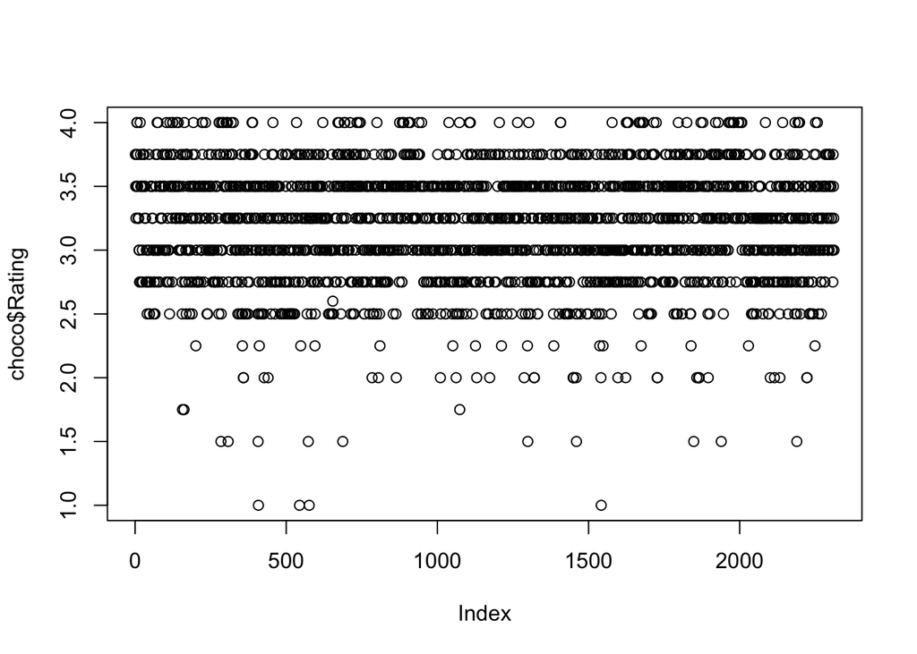

```r
#All defaults
plot(choco$Rating)
```

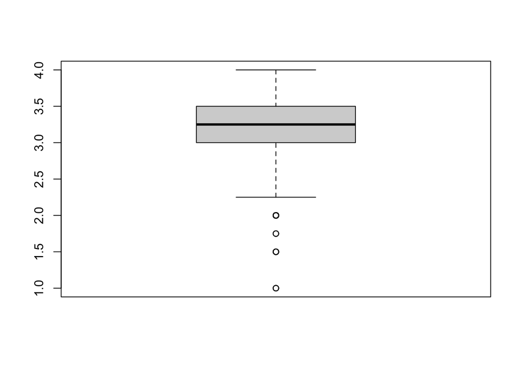

```r
boxplot(choco$Rating)
```

## 2. How does the number of ratings depend on the location of the company? Draw a bar chart of the number of reports.

```r
#All defaults
reports <- table(choco$Location)
str(reports)
```

```
##  'table' int [1:67(1d)] 12 9 53 30 59 2 24 161 2 25 ...
##  - attr(*, "dimnames")=List of 1
##   ..$ : chr [1:67] "Amsterdam" "Argentina" "Australia" "Austria" ...
```

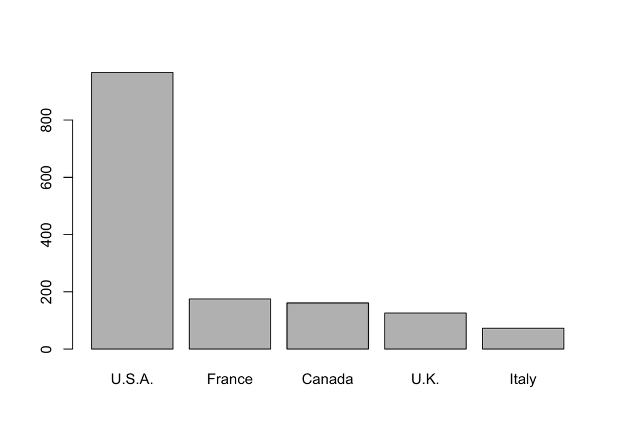

```r
best5 <-head(sort(reports,decreasing=TRUE),n=5)
barplot(best5)
```

## 3. Do ratings depend on the cacao percentage of a chocolate bar? Create both numerical and graphical summaries, and explain. [Hint: Think about why the scatterplot is not a very good choice for visualization here.]

```r
#All defaults
cor(choco$Cocoa_Percent, choco$Rating)
```

```
## [1] -0.1510178
```

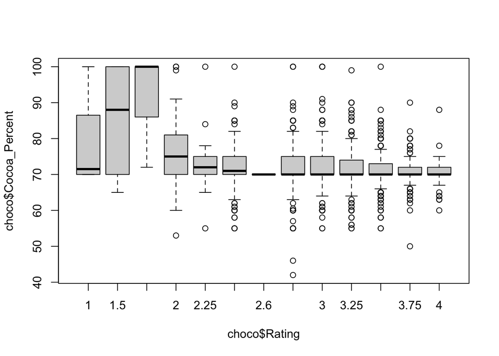

```r
boxplot(choco$Cocoa_Percent ~ choco$Rating)
```

It appears that the percentage of the cacao powder in a chocolate bar has a negative correlation with the rating. According to the box plot, the chocolate bars that have a large average percentage of cacao powder in them typically have lower ratings than the ones that have a lower amount of cacao powder in them. All the higher rated chocolate bars have an average of 70 cacao powder in them.

## 4. How do different bean origins compare in terms of the flavor of chocolates? Are beans from some places better than the other? Create both numerical and graphical summaries, and explain.

```r
#All defaults
origin <- table(choco$Bean_Origin)
str(origin)
```

```
##  'table' int [1:63(1d)] 3 67 1 151 72 1 75 1 3 66 ...
##  - attr(*, "dimnames")=List of 1
##   ..$ : chr [1:63] "Australia" "Belize" "blend" "Blend" ...
```

```r
origin5 <- head(sort(origin,decreasing=TRUE),n=5)
names(origin5)
```

```
## [1] "Venezuela"          "Peru"               "Ecuador"
## [4] "Dominican Republic" "Madagascar"
```

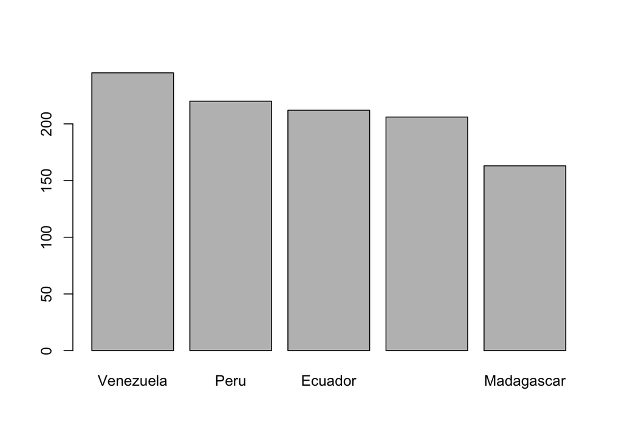

```r
barplot(origin5)
```

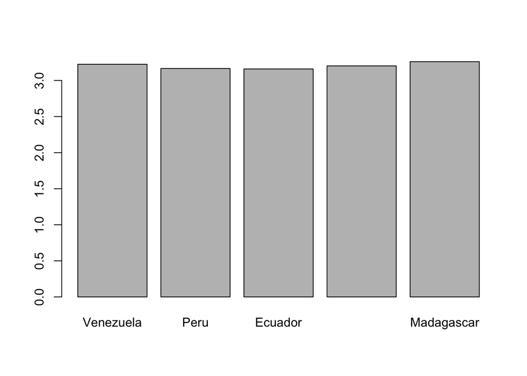

```r
#All defaults
venezuela <- choco[choco$Bean_Origin == 'Venezuela',]
peru <- choco[choco$Bean_Origin == 'Peru',]
ecuador <- choco[choco$Bean_Origin == 'Ecuador',]
dominican <- choco[choco$Bean_Origin == 'Dominican Republic',]
madagascar <- choco[choco$Bean_Origin == 'Madagascar',]
venrating <- venezuela$Rating
perurating <- peru$Rating
ecrating <- ecuador$Rating
domrating <- dominican$Rating
madrating <- madagascar$Rating
venave <- mean(venrating)
peruave <- mean(perurating)
ecave <- mean(ecrating)
domave <- mean(domrating)
madave <- mean(madrating)
averating <- c(venave, peruave, ecave, domave, madave)
names(averating) <- c('Venezuela','Peru','Ecuador','Dominican Republic','Madagascar')
barplot(averating)
```

```r
#All defaults
print(averating)
```

```
##          Venezuela               Peru            Ecuador Dominican Republic
##           3.224490           3.165909           3.159198           3.201942
##         Madagascar
##           3.260736
```

The five bean origins that had the most entries were Venezuela, Peru, Ecuador, Dominican Republic and Madagascar. As you can see by the numerical and graphical summaries, the average rating of the chocolates whose beans originated from these countries are very similar. They all had a rating of around 3.2. Out of these five origins, Madagascar had the highest average rating (3.26) while Ecuador had the lowest average rating (3.15). From this analysis, I don’t think that the origin of the beans has a lot to do with the quality of the chocolate.

## 5. Brainstorm two analyses you would like to perform (with your teammates). Describe in plain language what comparisons are you making. Create suitable numerical and graphical summaries for your analyses. Describe the results.

Our first analysis will be determining if the companies have any affect on rating. First, we will extract the 5 companies that have the most entries in the data set. Then, we will extract the rating data of these companies from the data set. After that, we will create a bar graph and print the average ratings.

```r
#All defaults
company <- table(choco$Company)
str(company)
```

```
##  'table' int [1:541(1d)] 3 25 4 4 4 2 1 3 6 4 ...
##  - attr(*, "dimnames")=List of 1
##   ..$ : chr [1:541] "5150" "A. Morin" "Acalli" "Adi aka Fijiana (Easy In Ltd)" ...
```

```r
company5 <- head(sort(company,decreasing=TRUE),n=5)
names(company5)
```

```
## [1] "Soma"   "Arete"  "Fresco" "Bonnat" "Pralus"
```

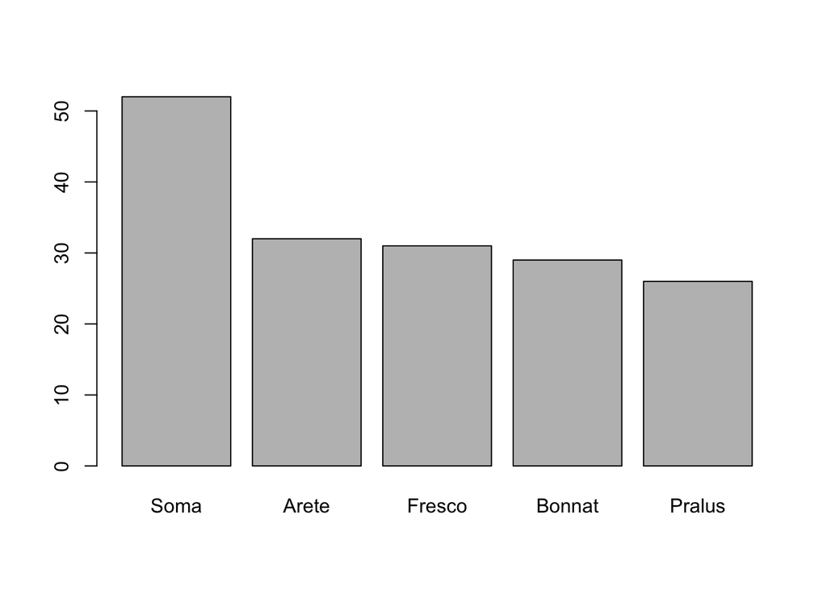

```r
barplot(company5)
```

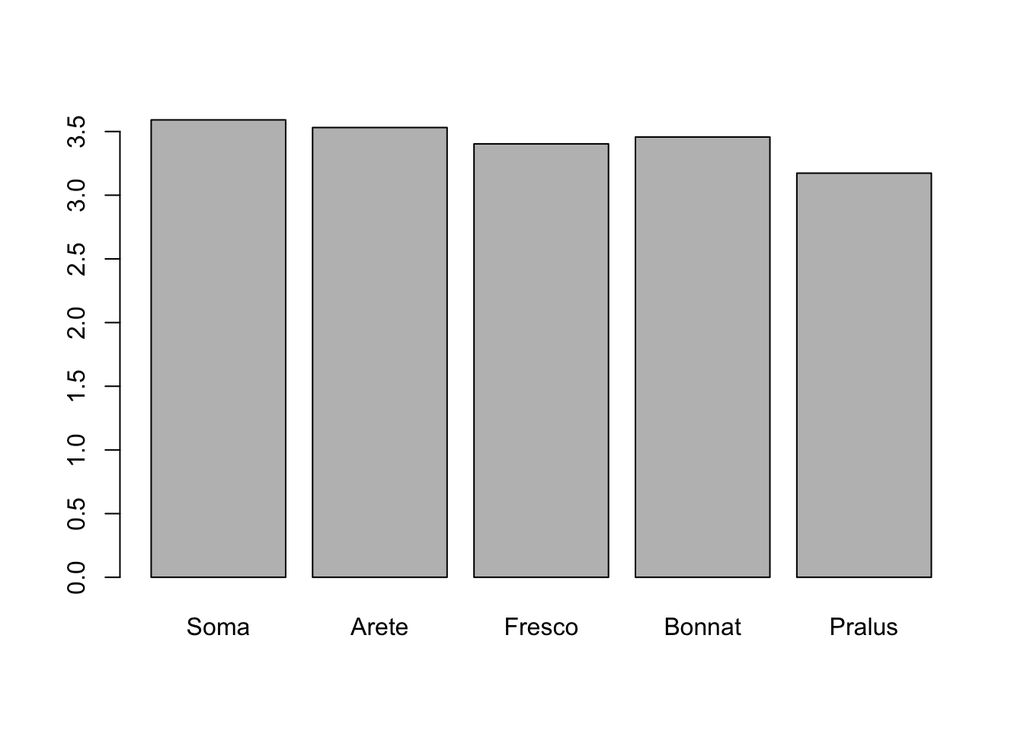

```r
#All defaults
soma <- choco[choco$Company == 'Soma',]
arete <- choco[choco$Company == 'Arete',]
fresco <- choco[choco$Company == 'Fresco',]
bonnat <- choco[choco$Company == 'Bonnat',]
pralus <- choco[choco$Company == 'Pralus',]
somarating <- soma$Rating
areterating <- arete$Rating
frescorating <- fresco$Rating
bonnatrating <- bonnat$Rating
pralusrating <- pralus$Rating
somaave <- mean(somarating)
areteave <- mean(areterating)
frescoave <- mean(frescorating)
bonnatave <- mean(bonnatrating)
pralusave <- mean(pralusrating)
averating <- c(somaave, areteave, frescoave, bonnatave, pralusave)
names(averating) <- c('Soma','Arete','Fresco','Bonnat','Pralus')
barplot(averating)
```

```r
#All defaults
print(averating)
```

```
##     Soma    Arete   Fresco   Bonnat   Pralus
## 3.591346 3.531250 3.403226 3.456897 3.173077
```

According to my data analysis, the five companies with the most entries are Soma, Arete, Fresco, Bonnat, and Pralus. These companies had more varied ratings than the bean origins did in problem 4. The highest rated company was Soma with an average rating of 3.59 and the lowest rating was Pralus with a 3.17. From this analysis, I think that the company does have an impact on rating, but only slightly.

For our second analysis, we are going to determine whether or not the date that the chocolate was made impacts the rating. We are going to take the five dates that have the most entries. Then, we will pull their rating information from the data set and calculate the average rating for each of these dates. We will make a graph and print the data.

```r
#All defaults
date <- table(choco$Date)
str(date)
```

```
##  'table' int [1:15(1d)] 62 73 92 123 110 163 194 184 247 284 ...
##  - attr(*, "dimnames")=List of 1
##   ..$ : chr [1:15] "2006" "2007" "2008" "2009" ...
```

```r
date5 <- head(sort(date,decreasing=TRUE),n=5)
names(date5)
```

```
## [1] "2015" "2014" "2018" "2016" "2019"
```

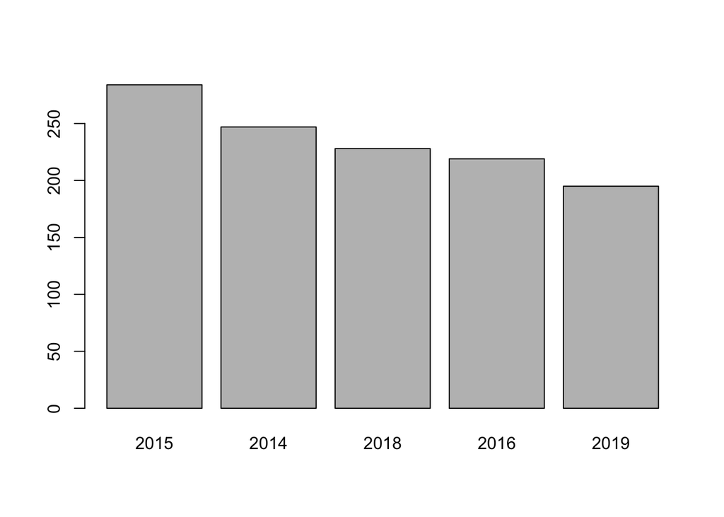

```r
barplot(date5)
```

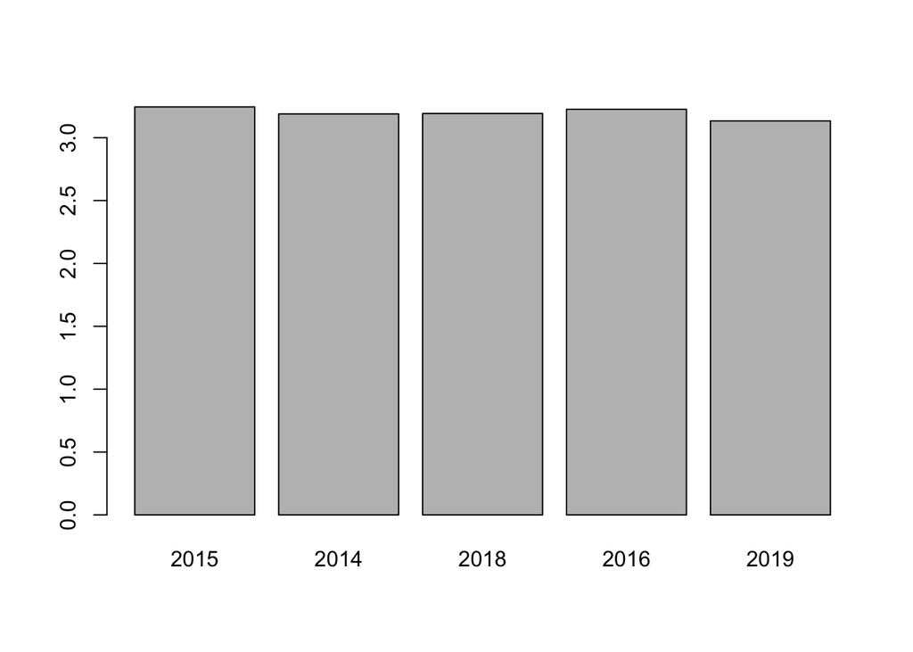

```r
#All defaults
fifteen <- choco[choco$Date == '2015',]
fourteen <- choco[choco$Date == '2014',]
eighteen <- choco[choco$Date == '2018',]
sixteen <- choco[choco$Date == '2016',]
nineteen <- choco[choco$Date == '2019',]
rating2015 <- fifteen$Rating
rating2014 <- fourteen$Rating
rating2018 <- eighteen$Rating
rating2016 <- sixteen$Rating
rating2019 <- nineteen$Rating
ave2015 <- mean(rating2015)
ave2014 <- mean(rating2014)
ave2018 <- mean(rating2018)
ave2016 <- mean(rating2016)
ave2019 <- mean(rating2019)
dateaverating <- c(ave2015, ave2014, ave2018, ave2016, ave2019)
names(dateaverating) <- c('2015','2014','2018','2016','2019')
barplot(dateaverating)
```

```r
#All defaults
print(dateaverating)
```

```
##     2015     2014     2018     2016     2019
## 3.244718 3.189271 3.192325 3.226027 3.133333
```

The five dates with the most entries in the data set are 2015, 2014, 2018, 2016, and 2019. The average ratings for all five of these years are fairly similar, they are all around 3.2. The highest rated date is 2015 with an average rating of 3.24, and the lowest rated year was 2019 with an average rating of 3.13. From this analysis, I don’t think that the year a chocolate was made has any impact on its flavor.